# Introduction to R

Author

Dr. Niloufar Abourashchi and Dr. Thomas Honnor

# Starting Out in R

R is a coding language focused on the interactive analysis of data. It was written as an open-source alternative to the S language, and along with Python is one of the most popular languages for applied data science.

## RStudio and the R console

To work and run R code we will use RStudio. This application is an IDE (Integrated Development Environment) that allows us to organise project files, edit code, run code, view results and even to write up our work.

Note: RStudio has other useful functionality for more advanced development work, for example version control, developing R packages, writing interactive data dashboards and web applications.

Typically when we work in RStudio we might see the window divided into four panels. In their default configuration, clockwise from top left:

- Source
- Environment/History
- Files/Plots/Packages/Help/Viewer
- Console

The placement of these panes and their content can be customized (see the menu bar, Tools $\rightarrow$ Global Options $\rightarrow$ Pane Layout).

One of the advantages of using RStudio is that all the information you need to write code is available in a single window. It also has useful data and editing tools, keyboard shortcuts, autocompletion, and code debugging tools.

For now we will concentrate only in the R Console panel, which allows us to type in and run commands. For example, if we type `1+1` and press enter R will show us the result.

## Maths in R

We can use R as a calculator using:

- `+` for addition: `2+3` gives `5`
- `-` for subtraction: `6-2` gives `4`
- `*` for multiplication: `4*7` gives `28`
- `/` for division: `27/3` gives `9`

**Try for yourself**

Try entering the following commands into the RStudio console, and press enter to see the result:

```r
123+456
```

```
[1] 579
```

```r
999999 / 810000
```

```
[1] 1.234567
```

### More maths operations

Some other useful R commands when carrying out calculations are:

- `^` or `**` for raising to a power: `10^2` and `10**2` both give `100`
- `sqrt` for taking the square root: `sqrt(16)` gives `4`
- `exp` for taking the exponential: `exp(2)` gives `7.389056`
- `log` for the natural logarithm: `log(7.389056)` gives `2`
- `log10` for the logarithm to base $10$: `log10(1000)` gives `3`
- `abs` for the absolute value: `abs(-2.5)` gives `2.5`

The commands like `sqrt` are R *functions* that take input *arguments* using brackets. That is, the command

```r
sqrt(25)
```

```
[1] 5
```

tells R to apply the function called `sqrt` to the input value `25`, producing the result `5`.

### Scientific notation

R uses `e`-notation for entering and displaying very large or small numbers in scientific format:

- `1e6` means $1\times 10^6=1 000 000$
- `2.5e-3` means $2.5\times 10^{-3}=0.0025$
- `-4e-4` means $-4\times 10^{-4}=-0.0004$

**Try for yourself**

Run the following commands and check that you understand the results:

```r
1000*1000
```

```
[1] 1e+06
```

```r
2.5/100000
```

```
[1] 2.5e-05
```

```r
3e3+44
```

```
[1] 3044
```

```r
1+2e-1
```

```
[1] 1.2
```

### Structuring calculations

**Try for yourself**

Run the following commands in R. What do you notice?

```r
5 + 3 + 2/4
```

```
[1] 8.5
```

```r
5+3+2 / 4
```

```
[1] 8.5
```

```r
5  +  3+2/4
```

```
[1] 8.5
```

Each one of the codes gives the same result: `8.5`. This is because in R the order of calculations is not affected by spaces, but is completed according to the standard PEMDAS system:

- **P**arentheses
- **E**xponents
- **M**ultiplication/**D**ivision
- **A**ddition/**S**ubtraction

**Try for yourself**

Try out each of the following commands and check that you understand the result produced:

```r
3/4+2
```

```
[1] 2.75
```

```r
3/(4+2)
```

```
[1] 0.5
```

```r
3*4^2
```

```
[1] 48
```

```r
(3*4)^2
```

```
[1] 144
```

```r
3*4^2+1
```

```
[1] 49
```

```r
3*4^(2+1)
```

```
[1] 192
```

Note that in order to make your code easier to read and understand you may add spaces and group expressions with brackets, even if they are not strictly necessary. This means that there will be an element of personal preference in how you structure your code.

**Exercises**

Use R to carry out each of the following calculations:

1. $1+(2+3+4)\times 6$
2. $\frac{24}{5}+7$
3. $\sqrt{400}$
4. $27^{1/3}+1$
5. $\sin(\pi/3)$

**Solution**

You should obtain the answers:

1. $55$
2. $11.8$
3. $20$
4. $4$
5. $0.8660254=\frac{\sqrt{3}}{2}$

## Variables

To help us work with information we store it as a variable. In R the convention is to use an arrow, `<-`, for assignment.

**Try for yourself**

Type the following into the console, pressing enter after each line:

```r
a <- 3
b <- 5
a+b
```

```
[1] 8
```

While the left-facing arrow is almost always the best approach, we can also use an equals sign, `=`, or a right-facing arrow, `->`, to assign data to variables.

```r
c = 4
5 -> d
e <- c+d
e
```

```
[1] 9
```

Note that when we press enter to run a command, R displays the result, except in cases when the output is being stored into a variable.

### Choosing names for variables

Variable names should be chosen to be concise but informative. They must start with a letter (not a number) and only contain letters, numbers and the dot, `.`, or underscore, `_`, character.

Variable names cannot use spaces, leading to different naming conventions to get around this:

- `snake_case_uses_underscores`, for example `population_by_country`
- `camelCaseUsesCapitals`, for example `populationByCountry`
- `we.can.instead.use.periods`, for example `population.by.country`

You are free to choose which you prefer, but it is good practice to be consistent within your code files.

Note:

- Take care to avoid variable names that might overwrite inbuilt commands, for example `plot`, `mean`, `max`. A simple way to do this may be to add a prefix, for example `my_plot`.
- R is case sensitive. This means `temp` and `Temp` are not equivalent.

### Types of variables

We need to deal with many different types of data (e.g. numerical, text, categorical), and we also need to deal with collections of data (e.g. lists, tables).

R contains object classes that let us store and work with these different types of data. Below are some of the common object classes we will work with:

- integer – these are whole numbers, for example `1`, `-999`, `6752`
- numeric – these are floating point numbers, for example `1.00`, `-9.99`, `0.6752`
- logical – these are boolean values, for example `TRUE`, `FALSE`
- character – these are text (also referred to as strings), for example `some text`, `R is great!`
- factor – these associate character labels to numerical levels, for example `healthy`, `diseased`

To check the class of a variable, we can use the `class` function:

```r
a <- "a test string"
class(a)
```

```
[1] "character"
```

Note that we can also use single quotes, `'`, to denote the start and end of text strings. It doesn’t matter which we use, but we must use the same symbol at both the start and the end of the text string.

```r
wizard <- 'Harry Potter'
wizard
```

```
[1] "Harry Potter"
```

### Ways to investigate variables

We can look at the contents of a variable using the `print` command. You may also see code examples that use alternative commands: `cat` (con*cat*entate and print) or `str` (display *str*ucture).

When we create variables, we say that they are added to our environment. We can see the variables defined in our environment using the `ls` (*l*i*s*t) command or by looking in the Environment tab in top right RStudio panel.

We can remove a variable from the environment using the `rm` command:

```r
a <- 4
ls()
```

```
[1] "a"               "b"               "c"               "d"
[5] "e"               "has_annotations" "wizard"
```

```r
rm(a)
ls()
```

```
[1] "b"               "c"               "d"               "e"
[5] "has_annotations" "wizard"
```

To delete all variables from our environment, we can either click on the broom icon in the Environment tab, or use the command `rm(list=ls())`.

RStudio will help autocomplete your commands and variable names as you type. For example, enter the following code:

```r
very_long_variable_name <- 999
```

On the next line, if you type `very` you should see the autocomplete options pop up, and you can select an item using the tab key. Similarly if you type `sqr` you should see the autocomplete suggest the function `sqrt()`, and you can press tab to accept the suggestion.

## Vectors

Often we want to store a set of data values in R where each value is of the same type, for example numeric. In this case, we can store it in a vector.

We create these using the `c` command (for concatenate/combine).

```r
my_vector <- c("a","b","c","d","e")
print(my_vector)
```

```
[1] "a" "b" "c" "d" "e"
```

```r
class(my_vector)
```

```
[1] "character"
```

```r
str(my_vector)
```

```
 chr [1:5] "a" "b" "c" "d" "e"
```

Note: if you forget to use `c` when defining a function you will see an error like:

```r
my_vector2 <- ("a","b","c","d","e")
```

```
Error: <text>:1:19: unexpected ','
1: my_vector2 <- ("a",
                      ^
```

You will undoubtedly write code which contains errors, and from this develop skills in interpreting error messages output by R.

### Retrieving data from vectors

We can use the length function to determine how many items are stored in a vector:

```r
my_vector <- c("a","b","c","d","e")
length(my_vector)
```

```
[1] 5
```

We can use square brackets, `[` and `]`, to access the items in a vector, by referring to an item’s index (first item has index 1, second has index 2, and so on).

**Single index method**

This lets us retrieve a single value from the vector:

```r
my_vector[1]
```

```
[1] "a"
```

```r
my_vector[2]
```

```
[1] "b"
```

**Multiple index method**

We can use a vector of indices to select multiple items:

```r
my_vector[c(1,3,5)]
```

```
[1] "a" "c" "e"
```

**Index slice method**

We can use `:` in the format `start_index:end_index` to make a sequence of indices to select:

```r
my_vector[1:3]
```

```
[1] "a" "b" "c"
```

**Negative selection method**

If we want all items except certain indices, we can use a negative selection using the `-` operator:

```r
my_vector[-3]
```

```
[1] "a" "b" "d" "e"
```

We can also use negative selection with a vector of indices:

```r
my_vector[-c(2,4,5)]
```

```
[1] "a" "c"
```

### Numerical Vectors

It is possible to apply mathematical operators to vectors that contain numbers.

**Try for yourself**

Create the following vectors in R:

```r
a <- c(1,2,3,4,5)
b <- c(6,7,8,9,10)
```

Run the following commands and check you understand the results:

```r
a+b
```

```
[1]  7  9 11 13 15
```

```r
a*b
```

```
[1]  6 14 24 36 50
```

```r
a^a
```

```
[1]    1    4   27  256 3125
```

```r
log(a)
```

```
[1] 0.0000000 0.6931472 1.0986123 1.3862944 1.6094379
```

```r
c <- a+b
c
```

```
[1]  7  9 11 13 15
```

```r
d <- a^b
d
```

```
[1]       1     128    6561  262144 9765625
```

Vector operations are carried out item-wise, that is if we add vectors `a` and `b` then the first item in vector `a` is added to the first item in vector `b` and so on.

If we ask R to perform a calculation with vectors of different lengths, R will recycle the numbers from the shorter vector to carry out the calculation, for example

```r
c(1,2,3,4,5,6) + c(10,0)
```

```
[1] 11  2 13  4 15  6
```

This can be useful, but can also hide issues (for example, R won’t necessarily tell us when the vectors in a calculation have different lengths).

### Generating vectors

The `rep` command lets us generate a vector by replicating a single value (or set of values). The first argument passed to the function is what to repeat and the second argument is how many times to repeat it:

```r
a <- rep(0,5)
a
```

```
[1] 0 0 0 0 0
```

```r
v1 <- rep(c("a","b","c"),2)
v1
```

```
[1] "a" "b" "c" "a" "b" "c"
```

We can using indexing to replace the values stored in a vector:

```r
a <- rep(0,5)
a
```

```
[1] 0 0 0 0 0
```

```r
a[3] <- 7
a
```

```
[1] 0 0 7 0 0
```

The `seq` function lets us generate a sequence in R. To use it, you must specify the start and end values:

```r
seq(1,10)
```

```
 [1]  1  2  3  4  5  6  7  8  9 10
```

Here, 1 and 10 are the `seq` function’s arguments. In general, to find out which arguments a function uses we look at the function documentation using the `help` function

**Try for yourself**

Open the documentation for the `seq` function by either typing `help(seq)` or typing the shortcut `?seq`).

The documentation shows you some of the ways to use the function, and the input arguments that we can specify. For example, we might call the `seq` function using

```r
b <- seq(from=0, to=10, by=2)
b
```

```
[1]  0  2  4  6  8 10
```

### Useful vector functions

There are many useful functions which operate on vectors, for example: `sum`, `min`, `max`, `range`, `mean`, `median`, `var`, `sd`, `sort`.

```r
d <- c(20,2,8,3)
sum(d)
```

```
[1] 33
```

```r
min(d)
```

```
[1] 2
```

```r
sort(d)
```

```
[1]  2  3  8 20
```

**Exercises**

A seller has auctioned a number of iPhones on eBay and wants to explore their sales data.

Create a vector that stores the price in pounds of the sold phones: 621, 455, 650, 600, 625, 646, 640, 750, 480, 629, 690, 600.

1. What is the total money which has been raised?
2. How many iPhones were sold?
3. What was the mean price paid?
4. What was the maximum price paid?
5. What was the minimum price paid?

**Solution**

One way to obtain the answers is:

```r
iphone_sales <- c(621, 455, 650, 600, 625, 646, 640, 750, 480, 629, 690, 600)
sum(iphone_sales)
```

```
[1] 7386
```

```r
length(iphone_sales)
```

```
[1] 12
```

```r
mean(iphone_sales)
```

```
[1] 615.5
```

```r
max(iphone_sales)
```

```
[1] 750
```

```r
min(iphone_sales)
```

```
[1] 455
```

# More R commands

At the start of a new section, we will clear R from all of our previously created objects.

```r
rm(list=ls())
```

## Relational and logical operators

In addition to the mathematical operations that let us perform calculations, there are relational operators such as `>`, or greater than, which result in boolean `TRUE` or `FALSE` values. For example:

```r
age <- 21
age > 3
```

```
[1] TRUE
```

```r
age > 99
```

```
[1] FALSE
```

A more complete list of relational operators is:

- `>`, greater than, for which `age>70` returns `FALSE`
- `<`, less than, for which `age<70` returns `TRUE`
- `>=`, greater than or equal to, for which `age>=21` returns `TRUE`
- `<=`, less than or equal to, for which `age<=21` returns `TRUE`
- `==`, is equal to, for which `age==18` returns `FALSE`
- `!=`, is not equal to, for which `age!=18` returns `TRUE`

We can use relational operators on a vector. In that case the test is applied to each value in the vector, producing a vector containing logical `TRUE` or `FALSE` values.

**Try for yourself**

Run the following commands in R, and check that the output is in agreement with your expectations:

```r
mass_g <- c(210, 340, 250, 400, 390)
mass_g > 300
```

```
[1] FALSE  TRUE FALSE  TRUE  TRUE
```

```r
mass_g <= 250
```

```
[1]  TRUE FALSE  TRUE FALSE FALSE
```

```r
mass_g == 340
```

```
[1] FALSE  TRUE FALSE FALSE FALSE
```

```r
mass_g != 400
```

```
[1]  TRUE  TRUE  TRUE FALSE  TRUE
```

### Counting Tests

Often, we might want to count the number of entries in a vector that meet a certain condition. In this case, we can utilise the fact that R treats `TRUE` and `FALSE` values as having numerical values $1$ and $0$ respectively.

For example:

```r
TRUE+TRUE
```

```
[1] 2
```

```r
FALSE+FALSE
```

```
[1] 0
```

This means we can make use of the `sum` function to count the number of `TRUE` entries in a vector containing logical `TRUE`/`FALSE` values:

```r
vec1 <- c(TRUE, TRUE, TRUE, FALSE, TRUE, TRUE)
sum(vec1)
```

```
[1] 5
```

For example, to see how many entries in a vector are greater than 300:

```r
mass_g <- c(210, 340, 250, 400, 390)
sum(mass_g > 300)
```

```
[1] 3
```

### Combining tests

In some cases we might want to combine multiple tests. To do this, we can combine two tests using a logical operators such the and operator `&`. In this case the output will only be `TRUE` if both relations are `TRUE`:

```r
age <- 21
age>5 & age<99
```

```
[1] TRUE
```

```r
age>30 & age<99
```

```
[1] FALSE
```

There are a number of different logical operators:

- `&`, and, for which `age>=20 & age<=29` returns `TRUE`
- `|`, or, for which `age<18 | age>65` returns `FALSE`
- `!`, not, for which `!(age<=30)` returns `FALSE`

In the final example above you can see that brackets, `(` and `)`, can be used to structure expressions.

**Try for yourself**

Run the following commands in R, and check that the output is in agreement with your expectations:

```r
mass_g <- c(210, 340, 250, 400, 390)
(mass_g < 350) & (mass_g >= 250)
```

```
[1] FALSE  TRUE  TRUE FALSE FALSE
```

```r
(mass_g < 350) | (mass_g == 400)
```

```
[1]  TRUE  TRUE  TRUE  TRUE FALSE
```

```r
(mass_g < 250) & (mass_g > 250)
```

```
[1] FALSE FALSE FALSE FALSE FALSE
```

```r
!(mass_g < 350)
```

```
[1] FALSE FALSE FALSE  TRUE  TRUE
```

We can also use logical operators to combine vectors containing boolean, `TRUE`/`FALSE`, values.

In the following example, we assume the entries in the vector represent data on $6$ individuals, and whether they smoke or not. Note how we use an R shortcut to enter `TRUE` or `FALSE` values using `T` and `F`. As these represent boolean or logical values (and not character strings), they do not require quotes.

```r
smoker = c(T, F, T, F, F, T)
male = c(F, F, F, T, T, T)
```

To find which individuals are both smokers and male:

```r
smoker & male
```

```
[1] FALSE FALSE FALSE FALSE FALSE  TRUE
```

We see that only the final individual is a smoker and male.

To find which individuals are either a smoker or a male:

```r
smoker | male
```

```
[1]  TRUE FALSE  TRUE  TRUE  TRUE  TRUE
```

We see that all except the second individual are either male or smokers.

### The `which` function

It can also be useful to identify which index satisfies a condition. For example, we have two vectors storing student names and their grades from a test:

```r
students <- c("ann", "bob", "carl", "david", "elle")
grades <- c(93, 65, 45, 85, 67)
```

We can identify which students scored more than 70:

```r
which(grades > 70)
```

```
[1] 1 4
```

We can then use the result to select the corresponding names:

```r
high_score_index <- which(grades > 70)
high_score_index
```

```
[1] 1 4
```

```r
students[high_score_index]
```

```
[1] "ann"   "david"
```

We can also combine the commands together into a single line of code:

```r
students[which(grades>70)]
```

```
[1] "ann"   "david"
```

## Editing vectors

We have seen how we can update values in a vector using the index of an element we want to change:

```r
vec1 <- c(10, 20, 30, 40, 50, 60)
vec1
```

```
[1] 10 20 30 40 50 60
```

```r
vec1[3] <- 999
vec1
```

```
[1]  10  20 999  40  50  60
```

R also lets us select and change multiple values at once, using a slice (or multiple indices):

```r
vec1[4:6] <- 0
vec1
```

```
[1]  10  20 999   0   0   0
```

Another way to select elements from a vector is using a vector of logical `TRUE`/`FALSE` values of the same length. In this case only the elements matched with a `TRUE` value are selected:

```r
vec1 <- c(10, 20, 30, 40, 50, 60)
sel1 <- c(T, T, F, F, T, T)
vec1[sel1]
```

```
[1] 10 20 50 60
```

In this way, we can use a logical `TRUE`/`FALSE` vector to select elements to modify:

```r
vec1[sel1] <- 999
vec1
```

```
[1] 999 999  30  40 999 999
```

Recall from the last section, that the result of using a relational operator on a vector is a logical `TRUE`/`FALSE` vector. This means that we can use commands such as the below::

```r
vec1 <- c(10, 20, 30, 40, 50, 60)
vec1[vec1>=40] <- 0
vec1
```

```
[1] 10 20 30  0  0  0
```

This works because the `vec1>=40` command evaluates to a logical vector which selects the elements matching the condition, which in this case is the last three elements.

```r
vec1 <- c(10, 20, 30, 40, 50, 60)
vec1 >= 40
```

```
[1] FALSE FALSE FALSE  TRUE  TRUE  TRUE
```

With this in mind, our earlier example could have been made even simpler:

```r
students[which(grades>70)]
```

```
[1] "ann"   "david"
```

```r
students[grades>70]
```

```
[1] "ann"   "david"
```

## Adding to a vector

We might also want to extend vectors by adding elements. To do this, we can insert a new entry at the end:

```r
vec1 <- c(10, 20, 30, 40, 50, 60)
vec1
```

```
[1] 10 20 30 40 50 60
```

```r
vec1[7] <- 70
vec1
```

```
[1] 10 20 30 40 50 60 70
```

Alternatively, we can combine two vectors using the `c` function:

```r
vec2 <- c(10, 20, 30)
vec2
```

```
[1] 10 20 30
```

```r
vec3 <- c(100, 200, 300)
vec3
```

```
[1] 100 200 300
```

```r
vec4 <- c(vec2, vec3)
vec4
```

```
[1]  10  20  30 100 200 300
```

Note that if you insert an entry beyond the end of the vector, R will automatically use extra entries to pad the vector:

```r
vec1 <- c(10, 20, 30, 40, 50, 60, 70)
vec1
```

```
[1] 10 20 30 40 50 60 70
```

```r
vec1[10] <- 100
vec1
```

```
 [1]  10  20  30  40  50  60  70  NA  NA 100
```

Here R has filled the additional entries with `NA` values.

### `NA` values

In R, `NA` is a special value meaning Not Available. Real datasets often include missing values, and it is important to consider how these might affect the results of statistical analysis.

For example:

```r
vec1
```

```
 [1]  10  20  30  40  50  60  70  NA  NA 100
```

```r
mean(vec1)
```

```
[1] NA
```

The result is `NA` because if one of the inputs to a calculation is missing, then it is not possible to know what the answer is. To get around this, we can specify that we want to ignoring any missing values, using the argument `na.rm=T` to set `NA` remove to be `TRUE`:

```r
mean(vec1, na.rm=T)
```

```
[1] 47.5
```

Different functions may use different arguments to specify which action to take with `NA` values, so make use of the `help` function. For example, try `help(sum)` and check how `NA`s are handled by that function.

To locate missing values we can make use of the `is.na` function:

```r
is.na(vec1)
```

```
 [1] FALSE FALSE FALSE FALSE FALSE FALSE FALSE  TRUE  TRUE FALSE
```

As we have seen before, the `sum` function can be applied on the resulting logical vector to count the number of `NA` values:

```r
sum(is.na(vec1))
```

```
[1] 2
```

**Exercises**

Run the following code:

```r
a <- c(1, 2, 3, 4, 5, NA, 7, 8)
is.na(a)
!is.na(a)
```

Can you predict what the following vector, `b`. will store?

```r
b <- a[ !is.na(a) ]
```

**Solution**

Working from the inside out:

1. `is.na(a)` would pick out the sixth entry.
2. `!is.na(a)` will pick out everything but the sixth entry

`b` is therefore all entries of `a` but not the sixth entry. That is, `b` is only those entries of `a` which are not `NA`

# Introduction to Data Frames

## Matrices

Vectors store data in a one-dimensional structure with a single index (entry number). However, R can also store and manipulate matrices, which contain data arranged in two dimensions, with rows and columns. As with vectors in R, each item in a matrix object must be of a single type, e.g. integer, numeric, character.

$$\begin{align*}
v &= [1,2,3,6] \\
m &= \begin{pmatrix}
1 & 2 \\
6 & 3
\end{pmatrix}
\end{align*}$$

To create a matrix in R, use the `matrix` function. Before using a function, it is often useful to check the documentation: `?matrix` or `help(matrix)`.

In this case the help file reveals that `matrix` takes a number of inputs, but for now we focus on the first three:

- The data, the entries in the matrix
- The number of rows
- The number of columns

First, we create a simple matrix:

```r
x <- matrix(c(1,2,3,4) ,2,2)
x
```

```
     [,1] [,2]
[1,]    1    3
[2,]    2    4
```

By default R assumes that the function arguments are passed into the function in the same order shown in the help file. However, if we want to pass them in a different order or to make our code easier to understand, we can include argument names when calling the function:

```r
x <- matrix(data=c(1,2,3,4), nrow=2, ncol=2)
x
```

```
     [,1] [,2]
[1,]    1    3
[2,]    2    4
```

As the above example illustrates, R places the elements into the matrix column-by-column by default – starting at the top-left, working down the first column, then down the second column, and so on until reaching the lower-right. Alternatively, the `byrow=TRUE` option can be used to populate the matrix row-by-row.

```r
matrix(c(1,2,3,4),2,2,byrow=TRUE)
```

```
     [,1] [,2]
[1,]    1    2
[2,]    3    4
```

### Working with Matrices

Suppose that our data is stored in the matrix `A`.

```r
A <- matrix(1:16,4,4)
A
```

```
     [,1] [,2] [,3] [,4]
[1,]    1    5    9   13
[2,]    2    6   10   14
[3,]    3    7   11   15
[4,]    4    8   12   16
```

Here the code `1:16` is used to generate the vector of numbers $1$, $2$, $3$, …, $15$, $16$.

We can use the `dim` function to find the number of rows and columns in our matrix:

```r
dim(A)
```

```
[1] 4 4
```

We can make a selection from a matrix just as we did for vectors, but must specify two values. For example:

```r
A[2,3]
```

```
[1] 10
```

This selects the element corresponding to the second row and the third column. The first number after the open-bracket symbol, `[`, always refers to the row, and the second number always refers to the column. We can also select multiple rows and columns at a time, by providing vectors as the indices.

**Exercises**

Try to work out what the following commands will select. Check your understanding by running them in R.

```r
A[c(1,3),c(2,4)]
A[1:3,2:4]
```

**Solution**

```r
A[c(1,3),c(2,4)]
```

```
     [,1] [,2]
[1,]    5   13
[2,]    7   15
```

```r
A[1:3,2:4]
```

```
     [,1] [,2] [,3]
[1,]    5    9   13
[2,]    6   10   14
[3,]    7   11   15
```

The first command extracts the submatrix of entries in the first and third rows and the second and fourth columns.

The second command extracts the submatrix of entries in the first through third rows and the second through fourth columns (that is, it retains everything other than dropping the fourth row and the first column, so we could have achieved the same effect via `A[-4,-1]`).

In the cases where we want all columns for a certain set of rows (or vice versa) we can leave the selector empty. For example:

```r
A[1:3,]
```

```
     [,1] [,2] [,3] [,4]
[1,]    1    5    9   13
[2,]    2    6   10   14
[3,]    3    7   11   15
```

This provides us with all columns for the first three rows.

```r
A[,1:2]
```

```
     [,1] [,2]
[1,]    1    5
[2,]    2    6
[3,]    3    7
[4,]    4    8
```

This provides us with all rows for the first two columns.

We can also use a negative sign, `-`, in the index to tell R to keep all rows or columns except those indicated.

```r
A[-c(1,3),]
```

```
     [,1] [,2] [,3] [,4]
[1,]    2    6   10   14
[2,]    4    8   12   16
```

```r
A[-c(1,3),-c(1,3,4)]
```

```
[1] 6 8
```

## Data frames

In general, datasets we investigate may contain a mixture of number, text and category variables. To be able to work with this, R provides the data frame object class.

For example, suppose we have measurements related to student grades:

```r
name <- c("Lauren", "Marcelino", "Ramona")
student_id <- c(100213, 100214, 100215)
grade <- c(78.6, 83, 60.2)
gender <- c("F", "M", "F")
teacher <- c("Mr Smith", "Ms Clarke", "Mr Smith")
age <- c(20, 19, 18)
```

We cannot combine these variables into a matrix, because a matrix can only contain data of a single type. Instead, we can build a data frame object.

```r
grades_df <- data.frame(name, student_id, grade, gender, teacher, age)
grades_df
```

```
       name student_id grade gender   teacher age
1    Lauren     100213  78.6      F  Mr Smith  20
2 Marcelino     100214  83.0      M Ms Clarke  19
3    Ramona     100215  60.2      F  Mr Smith  18
```

The `data.frame` function is passed the set of vectors that form the columns of the dataset.

To view the data frame, we can alternatively use the print command:

```r
print(grades_df)
```

```
       name student_id grade gender   teacher age
1    Lauren     100213  78.6      F  Mr Smith  20
2 Marcelino     100214  83.0      M Ms Clarke  19
3    Ramona     100215  60.2      F  Mr Smith  18
```

Other useful functions to view data frame information are:

- `head`, to output only the first few rows of the data frame (useful for large datasets)
- `View`, to open a view (similar to a spreadsheet view) of the data frame
- `names`, to show the column names
- `str`, to show the structure of the data frame

Let’s use `str` to look at the structure of the data frame we have created:

```r
str(grades_df)
```

```
'data.frame':   3 obs. of  6 variables:
 $ name      : chr  "Lauren" "Marcelino" "Ramona"
 $ student_id: num  1e+05 1e+05 1e+05
 $ grade     : num  78.6 83 60.2
 $ gender    : chr  "F" "M" "F"
 $ teacher   : chr  "Mr Smith" "Ms Clarke" "Mr Smith"
 $ age       : num  20 19 18
```

We can see that R has created the columns with numerical data types for our numerical data, and character data types from the text vectors.

It is important to manage data so that entries are stored in appropriate data types because R will use this information to determine the precise implementation of general functions, such as those which plot data. In this case `gender` is not a character, but instead a category which can be used to group students, so would be better stored as a Factor data type. We will see how to convert this later.

Data frames also have row labels. We can see these using the `rownames` function:

```r
rownames(grades_df)
```

```
[1] "1" "2" "3"
```

By default we see these row labels were set to be text strings `“1”`, `“2”`, `“3”`, etc.

### Selecting data

Data frames are two-dimensional, so can make selections using row and column indices in the same way as we did previously for matrix objects.

**Try for yourself**

Try out and check that you understand the output of the following commands:

```r
grades_df[2,3]
```

```
[1] 83
```

```r
grades_df[1,1:3]
```

```
    name student_id grade
1 Lauren     100213  78.6
```

```r
grades_df[3,]
```

```
    name student_id grade gender  teacher age
3 Ramona     100215  60.2      F Mr Smith  18
```

```r
grades_df[,-2]
```

```
       name grade gender   teacher age
1    Lauren  78.6      F  Mr Smith  20
2 Marcelino  83.0      M Ms Clarke  19
3    Ramona  60.2      F  Mr Smith  18
```

**WARNING**

This is some people’s biggest pet-peeve with R and can cause errors which are frustrating to track down.

For example, you want to extract the data for all students with a `grade` of less than $70$ and write code to manipulate the resulting output as a data frame. However, because there is only one student with a `grade` of less than $70$, you actually end up with a vector, which might not play nice with some code written specifically for data frames. A small modification to the code, to extract data for all students with a `grade` of less than $80$, instead returns a data frame object.

The relevant help file in this case is `help(Extract)` (which itself is not easy to locate, as `help([)` doesn’t work). In that documentation, note the argument `drop=TRUE` as the default. It is this which automatically drops dimensions when they are not required (e.g. converting a one-dimensional data frame into a vector). Setting the argument `drop=FALSE` can therefore sometimes resolve unexpected errors when this behavious occurs.

We can also make selections using column or row labels.

**Try for yourself**

Try the following:

```r
grades_df["2","grade"]
```

```
[1] 83
```

```r
grades_df[,"teacher"]
```

```
[1] "Mr Smith"  "Ms Clarke" "Mr Smith"
```

```r
grades_df[,c("name","grade")]
```

```
       name grade
1    Lauren  78.6
2 Marcelino  83.0
3    Ramona  60.2
```

## Using `$` to select columns

R provides a useful shortcut for accessing columns by name from a data frame, using the dollar sign, `$`:

```r
grades_df$grade
```

```
[1] 78.6 83.0 60.2
```

Now that we know how to select a column, we can select the `student_id` numbers and use these to overwrite the default row labels:

```r
rownames(grades_df) <- grades_df$student_id
head(grades_df)
```

```
            name student_id grade gender   teacher age
100213    Lauren     100213  78.6      F  Mr Smith  20
100214 Marcelino     100214  83.0      M Ms Clarke  19
100215    Ramona     100215  60.2      F  Mr Smith  18
```

We can now remove the `student_id` column. We do this by selecting all columns except column $2$, and storing this back into `grade_df` (this overwrites the original data frame).

```r
grades_df <- grades_df[,-2]
```

**WARNING**

We need to be careful with code like this. If you run the above command multiple times it will drop the second column of the data frame, then again drop the second column of the resulting data frame, then again drop the second column of the resulting data frame, …, and if you run the command enough times then you will be left with only the first column of the original data frame remaining.

One way to avoid problems like this is to create a whole new object, e.g. `grades_df2`, but this can quickly lead to lots of similar objects which are hard to keep track of.

Another approach is to drop the column using its name, `grades_df <- grades_df[,names(grades_df)!="student_id"]`.

Yet another approach is to ensure that the code above appears very close to the code which initially generates `grades_df` and ensure that the multiple steps in the code are only ever run together. In that way, the second column of the data frame is only ever dropped at the point when it had its initial six columns.

Finally, we will correct the data type of the `gender` column, so that it is set to store data in Factor rather than character format.

We can convert a data type using a command like the following:

```r
as.factor(grades_df$name)
```

```
[1] Lauren    Marcelino Ramona
Levels: Lauren Marcelino Ramona
```

To convert a column, we may therefore overwrite it with the corrected data:

```r
grades_df$gender <- as.factor(grades_df$gender)
str(grades_df)
```

```
'data.frame':   3 obs. of  5 variables:
 $ name   : chr  "Lauren" "Marcelino" "Ramona"
 $ grade  : num  78.6 83 60.2
 $ gender : Factor w/ 2 levels "F","M": 1 2 1
 $ teacher: chr  "Mr Smith" "Ms Clarke" "Mr Smith"
 $ age    : num  20 19 18
```

Now, the `gender` column is a factor with levels (or categories) `"F"` and `"M"`, and the values `1 2 1` mean the first entries start category `1` (`"F"`), then category `2` (`"M"`), then category `1` (`"F"`).

## Graphics

The `plot` function is the default command to plot data in R. For instance, `plot(x,y)` produces a scatterplot of the numbers in `x` versus the numbers in `y`.

There are many additional options that can be passed in to the `plot` function. For example, passing in the argument `xlab` will result in a label on the x-axis.

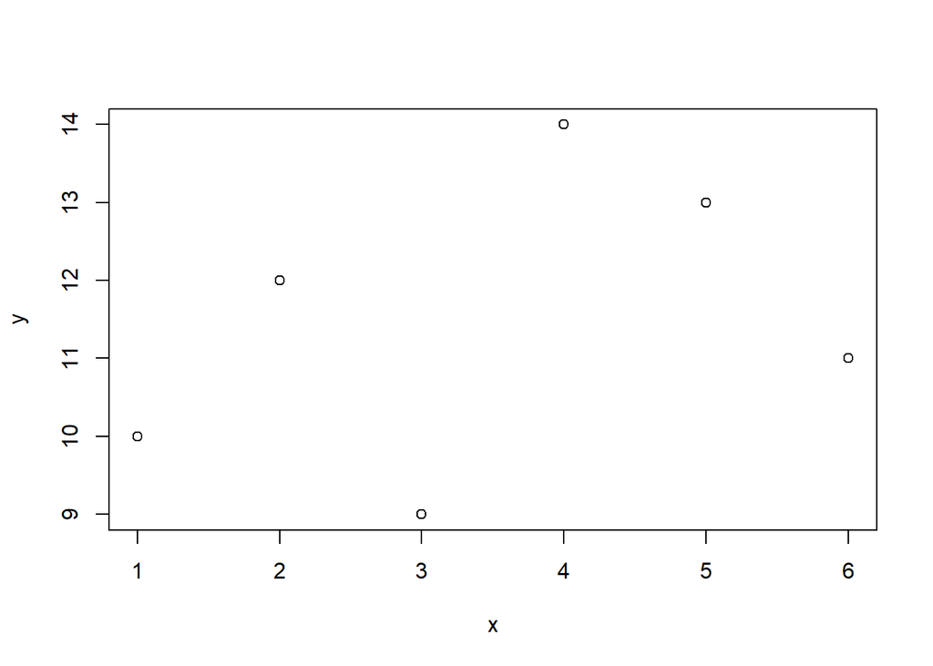

```r
x <- c(1,2,3,4,5,6)
y <- c(10,12,9,14,13,11)
plot(x,y)
```

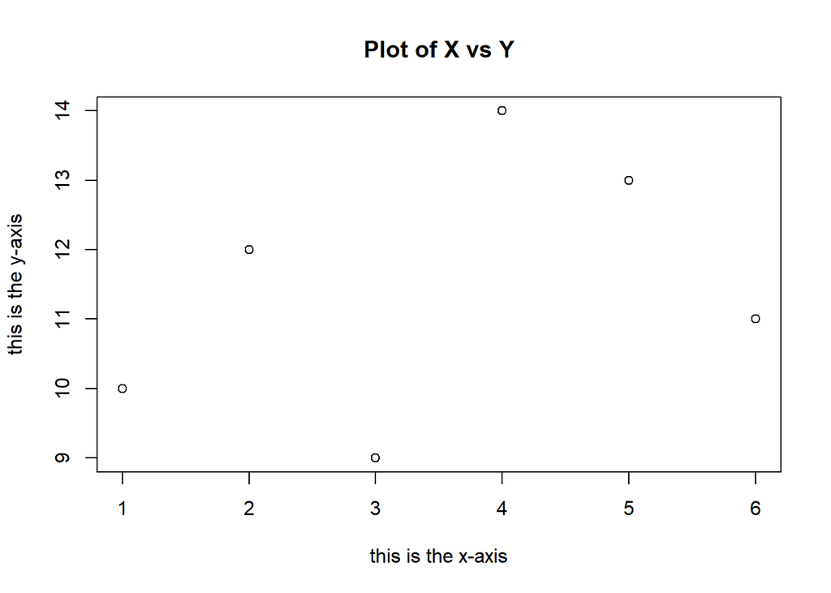

```r
plot(x, y, xlab = "this is the x-axis", ylab = "this is the y-axis", main = "Plot of X vs Y")
```

We will often want to save the output of an R plot. One easy way to do this is using the Export option in RStudio’s Plots pane menu (next to the Help and Files tab). From this we can save the image or copy it to the clipboard, so that it can be pasted into another application.

We can also save an image to disk. The command that we use to do this will depend on the file type that we would like to create. For instance, to create a png, we use the `png` function, and to create a pdf, we use the `pdf` function.

```r
png("my_firstfigure.png")
plot(x,y,col="green")
dev.off()
```

The function `dev.off` indicates to R that we are done creating the plot, and the resulting file should be saved and appear in the working directory. (You may need to click the refresh icon to see newly created files in the Files panel.)

The `par` function lets us specify graphics parameters. One useful argument is `mfrow` which defines an arrangement of plotted figures:

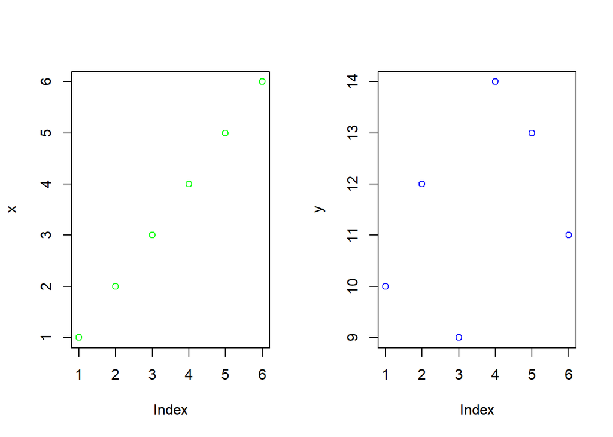

```r
par(mfrow=c(1,2))
plot(x, col="green")
plot(y, col="blue")
```

The two numbers here specify the number of plots in our figure by row and column, (that is, in this case one row and two columns of plots).

Note that we can reset the plotting window so that each figure comprises only a single plot by running the command `par(mfrow=c(1,1))`.